# TIER: Alcohol Exercise: Analysis and Narrative

Jenna R Krall

November 4, 2019

# 1) Introduction

The data were taken from Wechsler’s (2001) survey of students enrolled in 119 colleges and universities in the US.

In the original dataset for the study (0429-0001-Data.dta), and in the processed dataset we used to generate the figures for this exercise (analysis.RData), the unit of observation is a student. In other words, each record (row) in the dataset represents one student who completed the survey.

After all those deletions are made, the processed data file analysis.RData consists of 2,717 observations.

# 2) Figure 1.

Let’s use the term “heavy drinkers” to refer to students who report having gotten drunk at least three times in the last thirty days. Then figure 1 shows that the proportion of heavy drinkers is very similar among students living in alcohol-free housing and those not living in alcohol-free housing for both groups, the proportion is just over 30 percent. Although we have not done any test of statistical significance, we can tell by looking at the bar graph that the difference between the proportions for the two groups is small.

It would have seemed reasonable to expect that the proportion of heavy drinkers would be lower among students living in alcohol-free housing, but in figure 1 we find that is not the case.

```r
# Open "analysis.RData", using a relative path
# to specify that the data file is in the "Analysis-Data" folder
analysis <- load("Data/AnalysisData/analysis.RData")
```

## Figure 1. Students in Alcohol-Free versus not Alcohol-Free Housing.

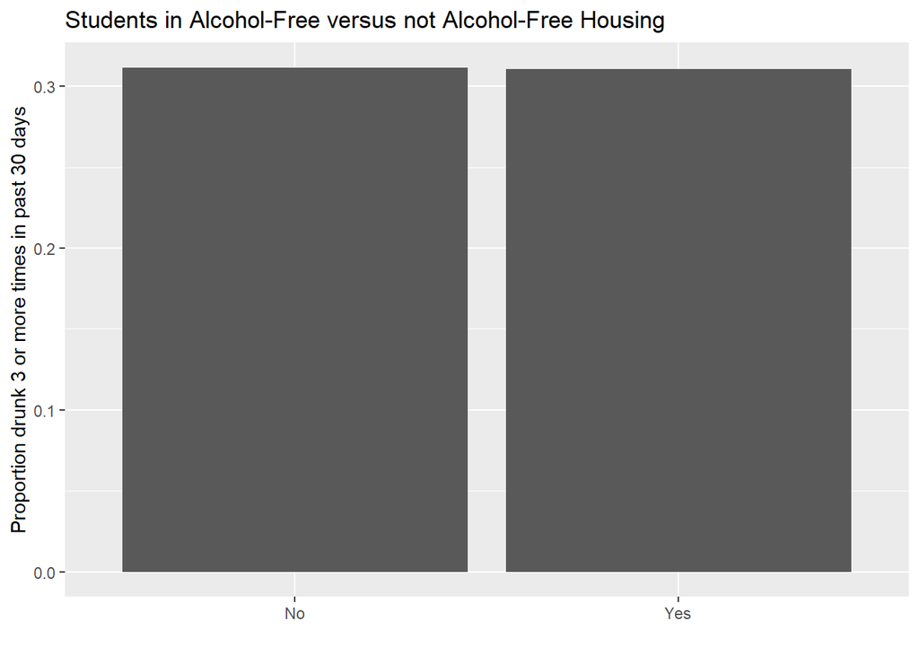

```r
# THIS COMMAND GENERATES FIGURE 1

# First, need to recode as dichotomous
dat <- mutate(dat, drunk30 = ifelse(drunk == "3 or more", 1, ifelse(drunk == "2 or fewer", 0, NA)))

# Make plot
ggplot(dat, aes(x = free, y = drunk30)) +
  geom_bar(stat = "summary", fun.y = "mean") +
  ylab("Proportion drunk 3 or more times in past 30 days") +
  xlab("") +
  ggtitle("Students in Alcohol-Free versus not Alcohol-Free Housing")
```

# 3) Figure 2.

Figure 2 shows that the proportion of heavy drinkers was lower among students who lived in alcohol-free housing because they requested it than among students who lived in alcohol-free housing because they were assigned to it. Compared to the overall rate of just over 30 percent observed in figure 1 for all students in alcohol-free housing, students who requested alcohol-free housing had a lower proportion of heavy drinkers (around 16 percent) and students assigned to alcohol-free housing had a larger proportion of heavy drinkers (around 38 percent).

The implication is that although (as seen in figure 1) the rates of heavy drinking are about the same in alcohol-free housing and non-alcohol-free housing, the rate is lower among students who chose to live in alcohol-free housing than among those who were assigned to live there.

## Figure 2. Students in Alcohol-Free Housing By Choice versus Assignment.

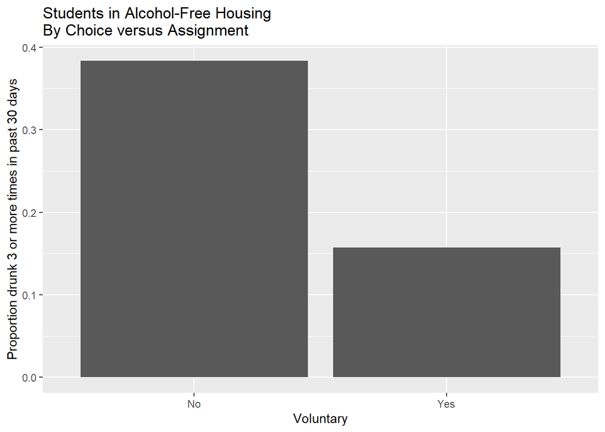

```r
# THIS COMMAND GENERATES FIGURE 2
datvol <- filter(dat, !is.na(volfree))
ggplot(datvol, aes(x = volfree, y = drunk30)) +
  geom_bar(stat = "summary", fun.y = "mean") +
  ylab("Proportion drunk 3 or more times in past 30 days") +
  xlab("Voluntary") +
  ggtitle("Students in Alcohol-Free Housing\nBy Choice versus Assignment")
```

# 4) Figure 1 vs. Figure 2.

All 2,717 students in the analysis.RData dataset are represented in figure 1, and 289 students are represented in figure 2.

The reason for this difference is that figure 2 used data only for students in alcohol-free housing. Consequently, the 1,909 individuals in the dataset who did not live in alcohol-free housing were excluded.

In addition, figure 2 used data only for individuals living in alcohol-free housing because they requested it or because they were assigned to it. Consequently, the 519 students who lived in alcohol-free housing because all campus housing was alcohol-free were excluded.

# 5) Figure 3.

The left-most bar (labeled “Not Alcohol-Free”) in figure 3 is identical to the left-most bar (labeled “Not in Alcohol-Free Housing”) in figure 1: both show that just over 30 percent of students not living in alcohol-free housing were heavy drinkers. 2

The bar (labeled “Assigned to alcohol-free housing”) that is second to the left in figure 3 is identical to the left-most bar (labeled “Not Voluntarily”) in figure 2: both show that about 38 percent of students not living in alcohol-free housing because they were assigned to it were heavy drinkers.

The only bar in figure 3 that is not represented in figure 1 or 2 is the one labeled “All campus housing alcohol-free.” It shows that the proportion of heavy drinkers in this group was near to 30 percent.

An interesting thing to note in figure 3 is that the proportion of heavy drinkers among students assigned to live in alcohol-free housing is greater than the proportion of heavy drinkers among students who do not live in alcohol-free housing. That suggests that forcing students to live in alcohol-free housing leads them to drink more than if they were just allowed to live in housing that was not alcohol-freeâmaybe there is something here related to some form of rebelliousness. That sounds like a reasonable hypothesis, but we don’t really know whether this causal story is correct. There may be something else going on; for instance, maybe a lot of the students who were assigned to live in alcohol-free housing had previously lived in non-alcohol- free housing and gotten into trouble for excessive drinking, and they were assigned to alcohol- free housing as a disciplinary measure. In that case, if the discipline were ineffective, we might end up with a lot of heavy drinkers assigned to live in alcohol-free housing.

## Figure 3. Drinking by Students in All Housing Types.

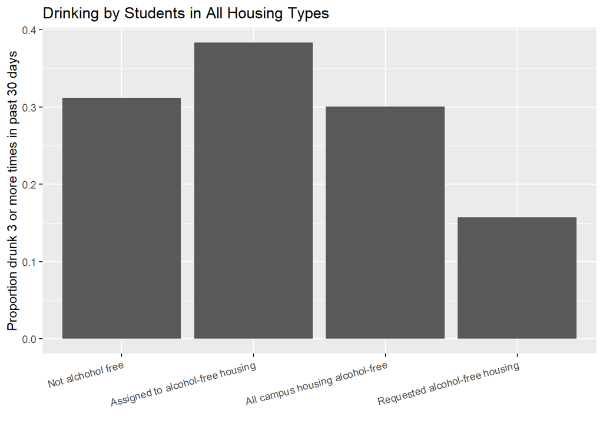

```r
# THIS COMMAND GENERATES FIGURE 3
ggplot(dat, aes(x = housing, y = drunk30)) +
  geom_bar(stat = "summary", fun.y = "mean") +
  ylab("Proportion drunk 3 or more times in past 30 days") +
  xlab("") +
  ggtitle("Drinking by Students in All Housing Types") +
  theme(axis.text.x = element_text(angle = 15, hjust= 1, vjust = 1))
```

```r
# Horizontal bars
ggplot(dat, aes(x = housing, y = drunk30)) +
  geom_bar(stat = "summary", fun.y = "mean") +
  ylab("Proportion drunk 3 or more times in past 30 days") +
  xlab("") +
  ggtitle("Drinking by Students in All Housing Types") +
  theme(axis.text.x = element_text(angle = 15, hjust= 1, vjust = 1)) +
  coord_flip()
```

[output not shown]

# 6) Figure 4.

Let’s use the term “high school drinkers” to refer to students who report having had five or more drinks in a row at least three times during senior year of high school.

Like figure 1, figure 4 shows the proportions of heavy drinkers in alcohol-free and non- alcohol-free housing, but figure 4 further disaggregates the data into high school drinkers and high school non-drinkers. We observe that, whether we consider high school drinkers or high- school non-drinkers, the proportion of heavy drinkers is about the same for students in alcohol- free housing and students not in alcohol-free housing. But these proportions differ for high school drinkers and high school non-drinkers: among high school non-drinkers, the proportions of drinkers (for residents of alcohol-free and non-alcohol-free housing) were a little under 20 percent; among high school drinkers, the proportions of drinkers (for residents of alcohol-free and non-alcohol-free housing) were about 53 percent.

## Figure 4. Students in Alcohol-Free versus not Alcohol-Free Housing Controlling for HS Drinking.

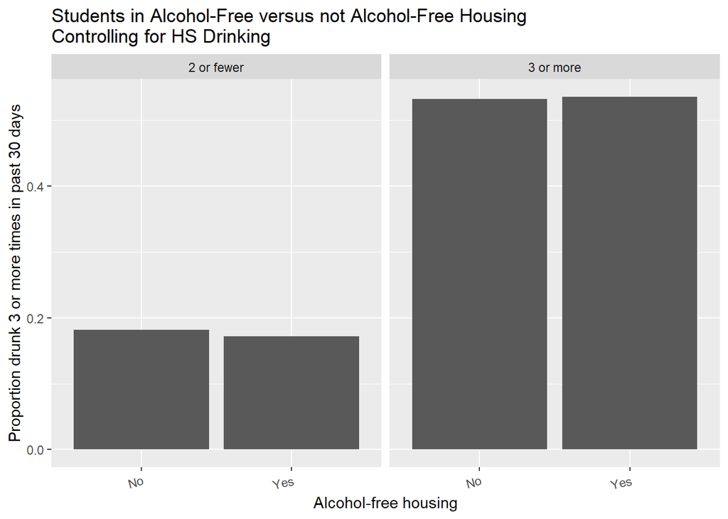

```r
# THIS COMMAND GENERATES FIGURE 4
ggplot(dat, aes(x = free, y = drunk30)) +
  geom_bar(stat = "summary", fun.y = "mean") +
  ylab("Proportion drunk 3 or more times in past 30 days") +
  xlab("Alcohol-free housing") +
  ggtitle("Students in Alcohol-Free versus not Alcohol-Free Housing\nControlling for HS Drinking") +
  theme(axis.text.x = element_text(angle = 15, hjust= 1, vjust = 1)) +
  facet_wrap(~ hsdrunk)
```

# 7) Figure 5.

## Figure 5. Students in Alcohol-Free Housing By Choice versus Assignment Controlling for HS Drinking

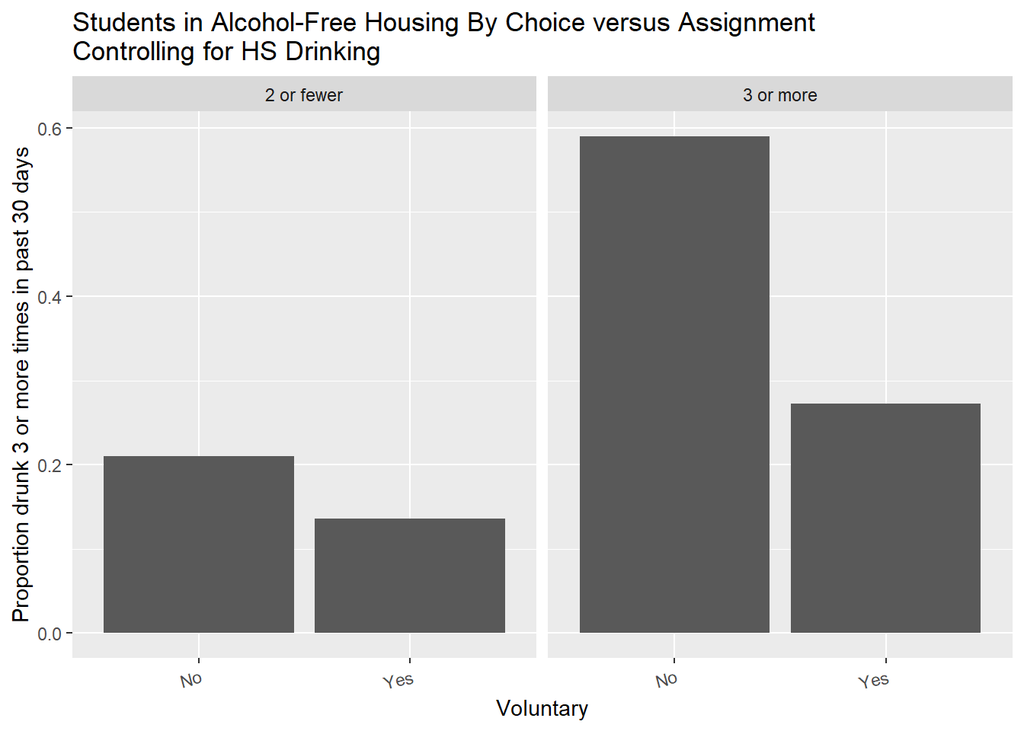

```r
# THIS COMMAND GENERATES FIGURE 5
ggplot(datvol, aes(x = volfree, y = drunk30)) +
  geom_bar(stat = "summary", fun.y = "mean") +
  ylab("Proportion drunk 3 or more times in past 30 days") +
  xlab("Voluntary") +
  ggtitle("Students in Alcohol-Free Housing By Choice versus Assignment\nControlling for HS Drinking") +
  theme(axis.text.x = element_text(angle = 15, hjust= 1, vjust = 1)) +
  facet_wrap(~ hsdrunk)
```

# 8) Figure 6.

Like figure 3, figure 6 shows the proportions of heavy drinkers among students living in each of the four types of housing defined by housing. The pattern we see when we compare figures 3 and 6 is analogous to the pattern we saw when we compared figures 2 and 5: whether we consider high school drinkers or high school non-drinkers, the proportions of heavy drinkers in the four categories *relative to one another* are similar to the relative proportions among the categories in figure 3; but for every housing category, the proportion of heavy drinkers is larger among high school drinkers than among high school non-drinkers.

## Figure 6. Students in All Housing Types Controlling for HS Drinking.

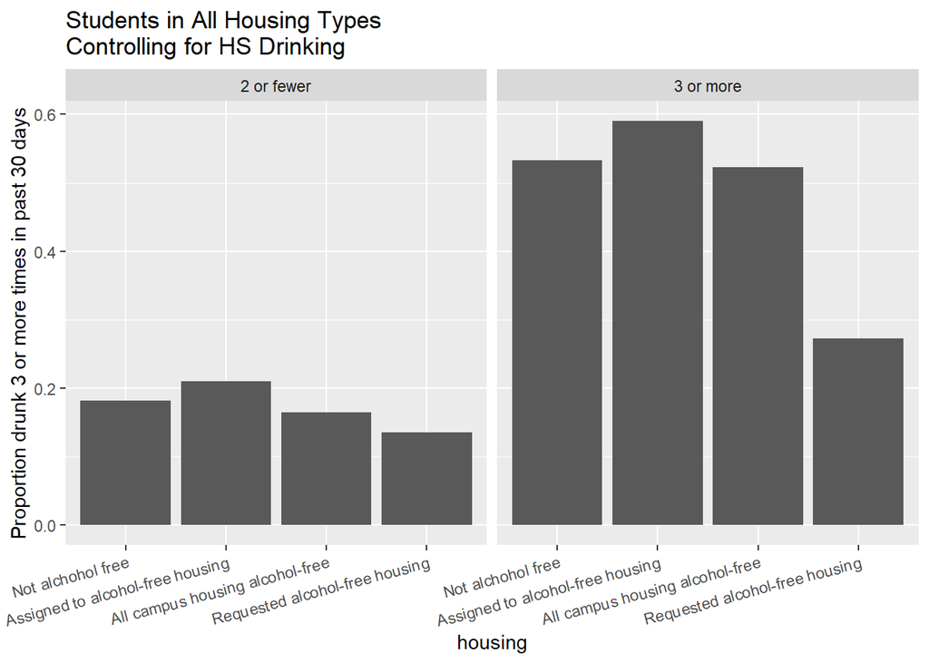

```r
# THIS COMMAND GENERATES FIGURE 6
ggplot(dat, aes(x = housing, y = drunk30)) +
  geom_bar(stat = "summary", fun.y = "mean") +
  ylab("Proportion drunk 3 or more times in past 30 days") +
  ggtitle("Students in All Housing Types\nControlling for HS Drinking") +
  theme(axis.text.x = element_text(angle = 15, hjust= 1, vjust = 1)) +
  facet_wrap(~ hsdrunk)
```

# 9) Summary

# Reference

Wechsler, Henry. Harvard School of Public Health College Alcohol Study, 2001. ICPSR04291- v2. Ann Arbor, MI: Inter-university Consortium for Political and Social Research [distributor], 2008-02-05. http://doi.org/10.3886/ICPSR04291.v2